# heatmap avec max

Florence Pittion

2021-06-02

# 1 Requirements

**Data**

This study is based on following data set:

- methylation data from normal tissues (Illumina 450k: GSE56515, GSE48472, GSE64096, GSE50192", GSE31848", GSE73375)

# 2 Pipeline

**Genes with CpG rich TSS**

We use definition of transcripts proposed by UCSC, version hg38 (`genome`).

From genomic sequence of the promoter of each gene (`genes.bed`), we compute a CpG density value. Job is done there `~/projects/genes/02_tss_cpg_status.Rmd`, including PCA analisis.

Distribution of CpG density clearly shows two population (results).

The file `genes.bed` is enriched with new colomn called `tss_cpg_status`.

```r
table(genes$tss_cpg_status)
```

```
#>
#> cpg_poor cpg_rich
#>    10139    15928
```

```r
gs_cpgrich = rownames(genes)[!is.na(genes$tss_cpg_status) & genes$tss_cpg_status=="cpg_rich"]
```

**Promoter methylation status in normal tissues**

```
#> Setting options('download.file.method.GEOquery'='auto')
#> Setting options('GEOquery.inmemory.gpl'=FALSE)
```

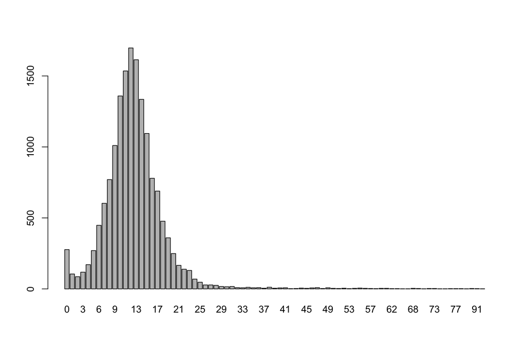

From Illumina 450k studies, we obtain a methylation matrix of 370 samples, dispatched into 31 tissues including connective_tissues, artery, bones_joints_cartilage, bone_marrow, heart, stomach, lymph_nodes, tonsil, bladder, gallbladder, brain, central_nervous_system, sperm, blood, liver, peritoneum_retroperitoneum, pancreas, spleen, mouth, skin, div_digestive, amnion, adrenal_gland, embryonic_stem_cells, induced_pluripotent_stem_cells, NA, kidney, thymus, ureter, bronchus_lung, placenta.

This matrix is successively reduced, first by tissues, then by genes with CpG rich promoter. The function used to reduce the data is the `max`.

[figure not shown]

```r
gs_methplusplus_max = rownames(data)[unlist(hm_max$rowDendrogram[[1]])]
length(gs_methplusplus_max)
```

```
#> [1] 9428
```